# Santa Barbara Landcover Classification

{Kristina Glass}

2023-12-15

# Introduction

*Credit: This project is based on materials developed by Chris Kibler.

Monitoring the distribution and change in land cover types can allow us to gain insights into the impacts of climate change, natural disasters, deforestation, urbanization, and over major phenomena. This is a major application of remote sensing due to the ability to distinguish different materials based on their spectral reflecance from this process, especially in large areas.

## Area of Interest

The area of interest for this study is Southern Santa Barbara County in California, which was first settled by the Chumash tribe around 13,000 years ago. Following the large-scale Spanish colonization of the area in the 1770s and subsequent statehood of California 100 years later, Santa Barbara County has grown into an industrialized region of the Southern California Coast, home to about 440,00 residents[1](https://en.wikipedia.org/wiki/Santa_Barbara_County,_California)

# Purpose of Study

# Data

**Landsat 5 Thematic Mapper**

- [Landsat 5](https://www.usgs.gov/landsat-missions/landsat-5)
- 1 scene from September 25, 2007
- bands: 1, 2, 3, 4, 5, 7
- Collection 2 surface reflectance product

**Study area and training data**

- polygon representing southern Santa Barbara county
- polygons representing training sites
  - type: character string with land cover type

# Workflow

```r
library(sf)
library(terra)
library(here)
library(dplyr)
library(rpart)
library(rpart.plot)
library(tmap)
library(ggplot2)

rm(list = ls())

here::i_am("assignments/santa_barbara_county_landcover_classification/sb_landcover.Rmd")
setwd(here())
```

## Create a Raster Stack

A list of all raster files are created to be put into the `rast` function to create the stack. The bands in the rasters are “blue”, “green”, “red”, “NIR”, “SWIR1”, and “SWIR2”.

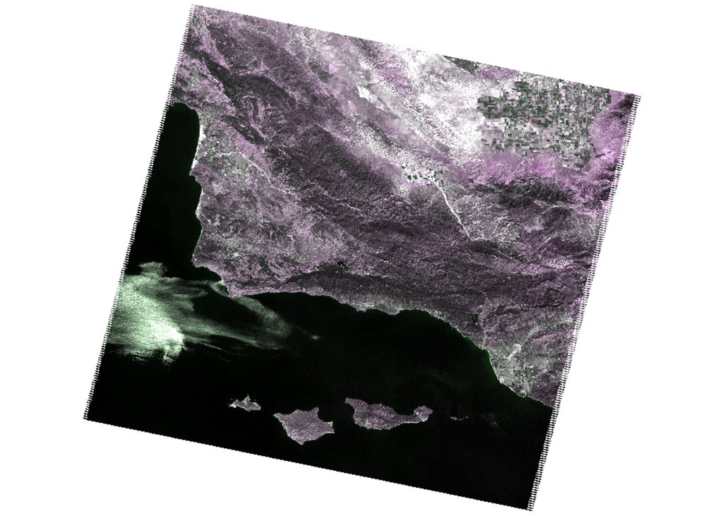

```r
# list files for each band, including the full file path
filelist <- list.files("data/landsat-data", full.names = TRUE)
# read in and store as a raster stack
landsat <- rast(filelist)

# update layer names to match band
names(landsat) <- c("blue", "green", "red", "NIR", "SWIR1", "SWIR2")

# plot true color image
plotRGB(landsat, r = 3, g = 2, blue = 1, stretch = "lin")
```

## Study Area

```r
# read in shapefile for southern portion of SB county
sb_county_south <- st_read("data/SB_county_south.shp")
```

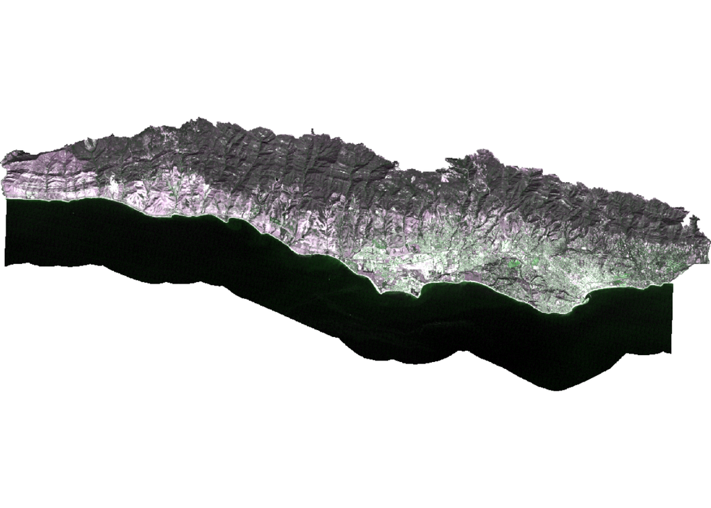

```r
# project to match the Landsat data
sb_county_south <- st_transform(sb_county_south, crs = st_crs(landsat))

# crop Landsat scene to the extent of the SB county shapefile
landsat_cropped <- crop(landsat, sb_county_south)
# mask the raster to southern portion of SB county
landsat_masked <- mask(landsat_cropped, sb_county_south)
# remove unnecessary object from environment
rm(landsat, landsat_cropped, sb_county_south)
#plot new dataframe
plotRGB(landsat_masked, r = 3, g = 2, blue = 1, stretch = "lin")
```

## Reflectance

The values of the raster stack need to be converted to reflectance values by removing erroneous values and apply any [scaling factors](https://www.usgs.gov/faqs/how-do-i-use-scale-factor-landsat-level-2-science-products#:~:text=Landsat%20Collection%202%20surface%20temperature,the%20scale%20factor%20is%20applied.) to convert to reflectance.

This project uses the [Landsat Collection 2](https://www.usgs.gov/landsat-missions/landsat-collection-2). The valid range of pixel values for this collection 7,273-43,636, with a multiplicative scale factor of 0.0000275 and an additive scale factor of -0.2. So we reclassify any erroneous values as `NA` and update the values for each pixel based on the scaling factors. Now the pixel values should range from 0-100%.

After reclassifying, the shapefile containing the different locations within the study area and the land cover types will be loaded in. From there, the spectral values at each site should be extracted to create a data frame that relates land cover types to their spectral reflectance.

```r
# view initial summary of raster
summary(landsat_masked)
```

```
##       blue           green            red             NIR
##  Min.   : 7675   Min.   : 7543   Min.   : 7274   Min.   : 7248
##  1st Qu.: 8178   1st Qu.: 8063   1st Qu.: 7667   1st Qu.: 7545
##  Median : 8387   Median : 8941   Median : 8890   Median :12507
##  Mean   : 8668   Mean   : 9097   Mean   : 9062   Mean   :11460
##  3rd Qu.: 8955   3rd Qu.: 9730   3rd Qu.: 9965   3rd Qu.:14306
##  Max.   :65535   Max.   :26662   Max.   :27885   Max.   :28029
##  NA's   :39855   NA's   :39855   NA's   :39855   NA's   :39855
##      SWIR1           SWIR2
##  Min.   : 7025   Min.   : 6936
##  1st Qu.: 7419   1st Qu.: 7356
##  Median :11940   Median : 9824
##  Mean   :11372   Mean   :10007
##  3rd Qu.:13962   3rd Qu.:11740
##  Max.   :25139   Max.   :24752
##  NA's   :39855   NA's   :39855
```

```r
# reclassify erroneous values as NA
rcl <- matrix(c(-Inf, 7273, NA,
         43636, Inf, NA),
       ncol = 3, byrow = TRUE) #create matrix to be used in reclassification

landsat<- classify(landsat_masked, rcl = rcl)
# adjust values based on scaling factor
landsat <- (landsat * 0.0000275 - 0.2)*100

summary(landsat)
```

```
##       blue           green            red             NIR
##  Min.   : 1.11   Min.   : 0.74   Min.   : 0.00   Min.   : 0.23
##  1st Qu.: 2.49   1st Qu.: 2.17   1st Qu.: 1.08   1st Qu.: 0.75
##  Median : 3.06   Median : 4.59   Median : 4.45   Median :14.39
##  Mean   : 3.83   Mean   : 5.02   Mean   : 4.92   Mean   :11.52
##  3rd Qu.: 4.63   3rd Qu.: 6.76   3rd Qu.: 7.40   3rd Qu.:19.34
##  Max.   :39.42   Max.   :53.32   Max.   :56.68   Max.   :57.08
##  NA's   :39856   NA's   :39855   NA's   :39855   NA's   :39856
##      SWIR1           SWIR2
##  Min.   : 0.10   Min.   : 0.20
##  1st Qu.: 0.41   1st Qu.: 0.60
##  Median :13.43   Median : 8.15
##  Mean   :11.88   Mean   : 8.52
##  3rd Qu.:18.70   3rd Qu.:13.07
##  Max.   :49.13   Max.   :48.07
##  NA's   :42892   NA's   :46809
```

```r
# plot true color image to check results

# check values are 0 - 100
```

[output not shown]

```r
# read in and transform training data

training_data <- st_read("data/trainingdata.shp") %>%
  st_transform(., crs = st_crs(landsat))
# extract reflectance values at training sites
training_data_values<- extract(landsat, training_data, df = TRUE)
# convert training data to data frame

training_data_attributes <- training_data %>%
  st_drop_geometry() #drop unessecary geometry
# join training data attributes and extracted reflectance values
sb_training_data <- left_join(training_data_values, training_data_attributes,
          by = c("ID" = "id")) %>% #join by matching column "ID"
  mutate(type = as.factor(type)) #turn "type" column containing vegetation types into factor
```

## Train Decision Tree Classifier

To train the decision tree, we first need to establish our model formula (i.e. what our response and predictor variables are). The `rpart` function implements the [CART algorithm](https://medium.com/geekculture/decision-trees-with-cart-algorithm-7e179acee8ff). The `rpart` function needs to know the model formula and training data you would like to use. Because we are performing a classification, the method is set to “class” `method = "class"`. We also set `na.action = na.omit` to remove any pixels with `NA`s from the analysis.

To understand how the decision tree will classify pixels, the results can be plotted. The decision tree is comprised of a hierarchy of binary decisions. Each decision rule has 2 outcomes based on a conditional statement pertaining to values in each spectral band.

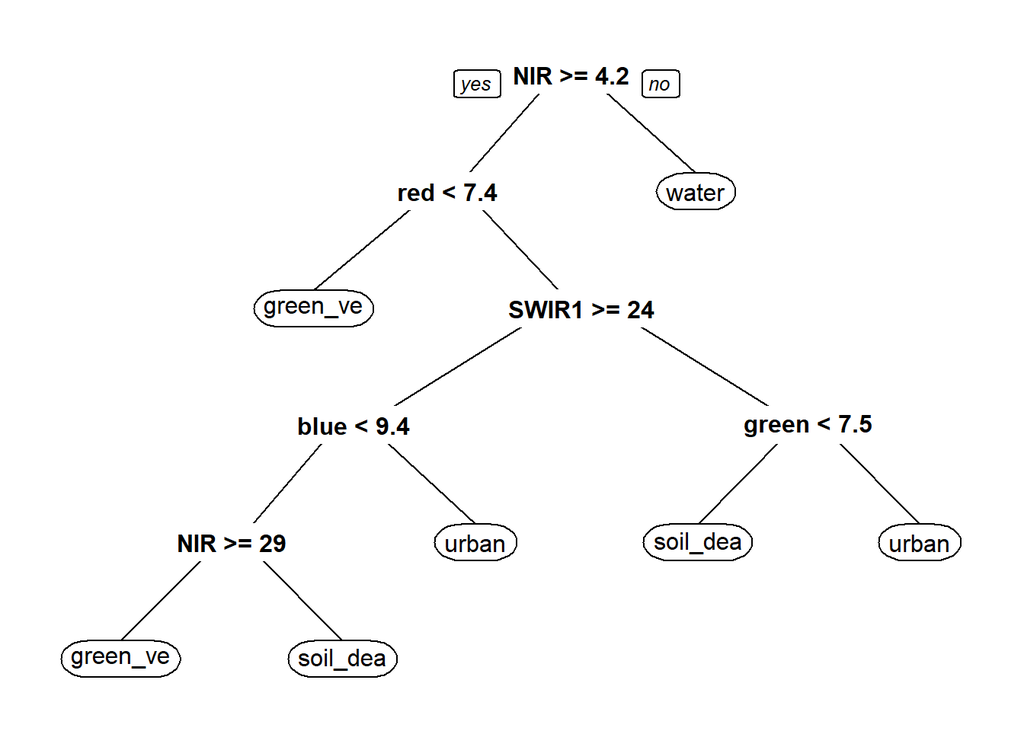

```r
# establish model formula
sb_formula <- type ~ red + green + blue + NIR + SWIR1 + SWIR2
# train decision tree
sb_decision_tree <- rpart(formula = sb_formula,
      data = sb_training_data,
      method = "class", #follow method mentioned above
      na.action = na.omit) #followed method mentioned above

# plot decision tree
prp(sb_decision_tree)
```

Once the decision tree is created, it can be applied to our entire image. The `terra` package includes a `predict()` function that allows you to apply a model to our data. In order for this to work properly, the names of the layers need to match the column names of the predictors we used to train our decision tree. The `predict()` function will return a raster layer with integer values. The integer values should correspond to the factor levels in the training data. To figure out what category each integer corresponds to, inspect the levels of our training data.

```r
# classify image based on decision tree
SB_classification <- predict(landsat, sb_decision_tree, type = "class", na.rm = TRUE)

# inspect level to understand the order of classes in prediction
levels(sb_training_data$type)
```

```
## [1] "green_vegetation" "soil_dead_grass"  "urban"            "water"
```

## Plot Results

```
## SpatRaster object downsampled to 621 by 1612 cells.
```

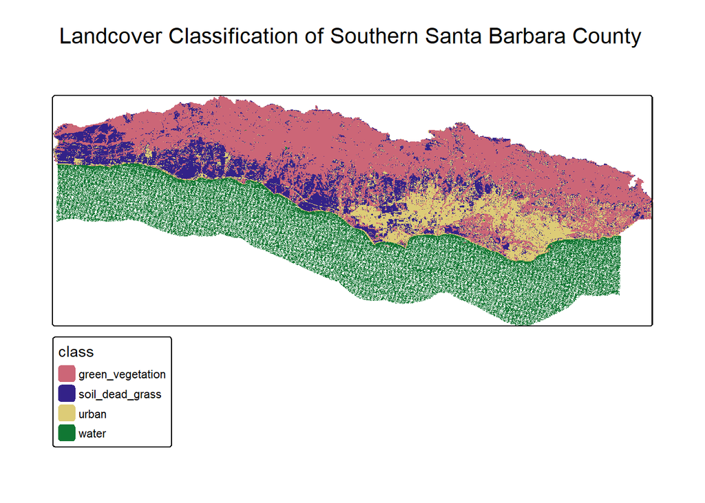

```r
# plot results

tm_shape(SB_classification) +
  tm_raster() +
  tm_title( "Landcover Classification of Southern Santa Barbara County" )
```

# Conclusion

Landcover classification can be useful in visualizing changes in landscapes over time, especially when used in combination with a Decision Tree Classifier. This analysis could function as the first step of a study identifying landcover changes in Santa Barbara County following large-scale development operations, or changes in landcover after natural disasters like the Thomas Fire in 2017.

# References

Berkeley, M. L. @. (2019, March 9). *Machine learning crash course: Part 5 - decision trees and ensemble models*. Medium. https://medium.com/@ml.at.berkeley/machine-learning-crash-course-part-5-decision-trees-and-ensemble-models-dcc5a36af8cd

Deepankar, deepankar. (2021, April 22). *Decision trees with CART algorithm*. Medium. https://medium.com/geekculture/decision-trees-with-cart-algorithm-7e179acee8ff

*How do I use a scale factor with landsat level-2 science products?*. How do I use a scale factor with Landsat Level-2 science products? | U.S. Geological Survey. (n.d.). https://www.usgs.gov/faqs/how-do-i-use-a-scale-factor-landsat-level-2-science-products#:~:text=Landsat%20Collection%202%20surface%20temperature,the%20scale%20factor%20is%20applied.

*Landsat 5*. Landsat 5 | U.S. Geological Survey. (n.d.). https://www.usgs.gov/landsat-missions/landsat-5

*Landsat collection 2*. Landsat Collection 2 | U.S. Geological Survey. (n.d.). https://www.usgs.gov/landsat-missions/landsat-collection-2

Wikimedia Foundation. (2023, December 12). *Santa Barbara County, California*. Wikipedia. https://en.wikipedia.org/wiki/Santa_Barbara_County,_California